# Descriptive statistics of variables after preprocessing

In the same way as what we stated in “Description of the preprocessing made in each variable”, we have the explanations that correspond to this category alongside the code that can be found after.

The structure of this file is similar to the previous ones: for each variable, we have a small section showing its results with a small analysis or observation of them. Not all variables have been modified, but since we deleted some rows, all of them are affected anyways, so we decided not to exclude any variable from this analysis, even if we’re only showing the small differences in their summary.

#### Variable provstate

As we can see in the barplot, California and New York are the most attacked states, much more than any other state.

[interactive chart not shown]

#### Variable city

In the following table, we can see the top 10 cities which have the biggest number of attacks recorded in the dataset. We can see that New York City has the most of all the cities by a huge margin, having more than four times the amount of incidents as San Juan, the city in second place. Moreover, taking into account the fact that the dataset records attacks of approximately the last 40 years, only the cities on the top of this table have a big amount of attacks and the rest of them only have occasional incidents: the number quickly goes down.

```
        City name Number of attacks
439 New York City               449
566      San Juan               107
364   Los Angeles               102
562 San Francisco                97
682    Washington                80
399         Miami                69
128       Chicago                54
594       Seattle                39
61       Berkeley                32
173        Denver                23
```

#### Variable latitude

Because of the purpose of latitude in this study, it’s not really relevant to analyze and visualize it now.

```r
summary(mydata$latitude)
```

```
   Min. 1st Qu.  Median    Mean 3rd Qu.    Max.
  17.97   34.10   38.91   36.84   40.70   64.84
```

#### Variable longitude

Because of the purpose of longitude in this study, it’s not really relevant to analyze and visualize it now.

```r
summary(mydata$longitude)
```

```
   Min. 1st Qu.  Median    Mean 3rd Qu.    Max.
-157.86 -117.87  -85.76  -92.13  -73.93  105.27
```

#### Variable doubtterr

Because of the meaning of this variable, it’s not necessary to give an analysis of it.

```r
summary(mydata$doubtterr)
```

```
   Mode   FALSE    TRUE    NA's
logical    2207     398     133
```

#### Variable success

```r
summary(mydata$success)
```

```
   Mode   FALSE    TRUE
logical     496    2242
```

As a logical variable we will represent it with a pie chart.

[interactive chart not shown]

We can see that there are many more successful acts (~82%) than unsuccessful ones (~18%).

#### Variable attacktype1_txt

```r
Mode(mydata$attacktype1_txt)
```

```
[1] Bombing/Explosion
8 Levels: Armed Assault Assassination ... Unarmed Assault
```

The most common method of attack type is “Bombing/Explosion”.

[interactive chart not shown]

The category which has most acts is “Bombing/Explosion” which has 49% of the acts, followed by “Facility/Infrastructure Attack” with 31%.

#### Variable targtype1_txt

```r
Mode(mydata$targtype1_txt)
```

```
[1] Business
21 Levels: Abortion Related Airports & Aircraft ... Violent Political Party
```

The most common target type is “Business”.

[interactive chart not shown]

The “Business” target type has 28% of the records.

#### Variable natlty1_txt

```r
Mode(mydata$natlty1_txt)
```

```
[1] United States
58 Levels: Angola Argentina Bahamas Bangladesh Brazil Canada ... Yugoslavia
```

Obviously the vast majority of the attacks are targeted towards the United States since that is the country we are studying.

We will remove the value United States and take the most significative ones in order to make a proper comparison between the other values.

```
   Nationality of victim Number of attacks
41           Puerto Rico                60
47          Soviet Union                45
12                  Cuba                20
26                Israel                14
34                Mexico                13
22         International                12
52                Turkey                12
23                  Iran                11
45          South Africa                11
57            Yugoslavia                10
16                 Egypt                 9
20                 Haiti                 9
55               Vietnam                 9
54             Venezuela                 8
21                 India                 6
```

#### Variable gname

```r
Mode(mydata$gname)
```

```
[1] <NA>
229 Levels: Action Squad African-American extremists ... Zebra killers
```

Most of the acts of terrorism were either claimed by individuals or an unknown group.

```r
f<-table(mydata$gname)
f1 = as.data.frame(f)
f2 = f1[order(-f1$Freq),]
f2 = subset(f2, f2$Freq > 20)
colnames(f2) = c ("Group name", "Number of attacks")
print(f2)
```

```
                                          Group name Number of attacks
12                          Anti-Abortion extremists               196
120                              Left-Wing Militants               169
88     Fuerzas Armadas de Liberacion Nacional (FALN)               109
143                New World Liberation Front (NWLF)                86
222                                 White extremists                85
52                                Black Nationalists                83
10                     Animal Liberation Front (ALF)                76
197                                 Student Radicals                71
109                      Jewish Defense League (JDL)                70
77                      Earth Liberation Front (ELF)                66
146                                          Omega-7                50
220                  Weather Underground, Weathermen                43
50                             Black Liberation Army                36
126                                       Macheteros                36
18                        Anti-Government extremists                33
57                          Chicano Liberation Front                31
39  Armed Revolutionary Independence Movement (MIRA)                30
25                            Anti-Muslim extremists                27
112                       Jihadi-inspired extremists                27
116                                     Ku Klux Klan                25
53                                    Black Panthers                24
165                        Puerto Rican Nationalists                23
196                                         Strikers                23
43                                       Army of God                21
73                                      Cuban Exiles                21
```

#### Variable nperps

```r
summary(mydata$nperps)
```

```
   Min. 1st Qu.  Median    Mean 3rd Qu.    Max.    NA's
   1.00    1.00    1.00    2.08    3.00   24.00    1941
```

The minimun value is 1 because it makes no sense that no perpetrator has commited a crime. In preprocessing we corrected those values by changing them to NA.

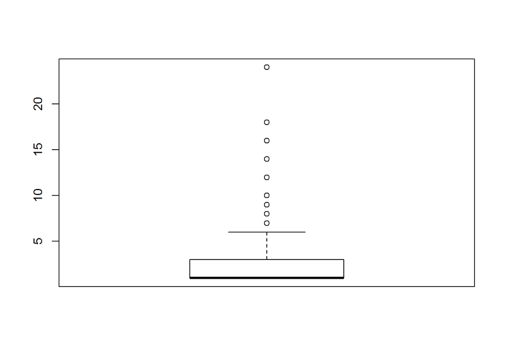

```r
boxplot(mydata$nperps)
```

As we can see in this boxplot most of the acts of terrorism in the United States were perpetrated by individuals that worked alone.

```r
skewness(mydata$nperps,na.rm = TRUE)
```

```
[1] 4.292201
```

This value tells us that this variable is asimetric, just as we have seen in the boxplot.

```r
kurtosis(mydata$nperps,na.rm = TRUE)
```

```
[1] 32.51557
```

This value tells us that there is an extreme peak in the distribution where most of the values are clustered. The peak is number 1.

#### Variable nperpcap

```r
summary(mydata$nperpcap)
```

```
   Min. 1st Qu.  Median    Mean 3rd Qu.    Max.    NA's
  0.000   0.000   1.000   1.239   1.500  11.000    1931
```

In this case the value 0 makes sense.

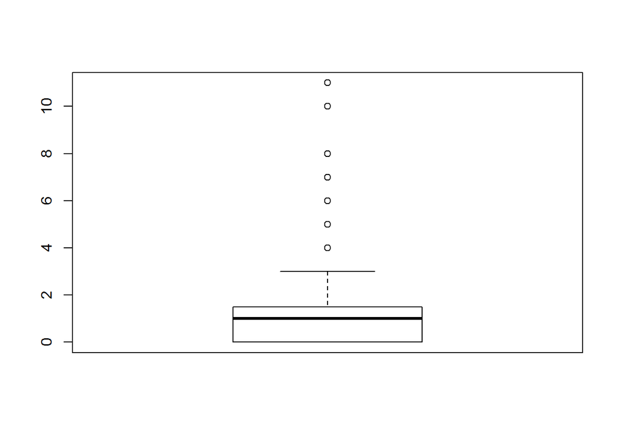

```r
boxplot(mydata$nperpcap)
```

As we can see in this boxplot most of the time 0, 1 or 2 perpetrators are captured.

```r
skewness(mydata$nperpcap,na.rm = TRUE)
```

```
[1] 2.244441
```

The positive value of skewness shows us that the variable value distribution is asimetric, its mode being a lower value than the median.

```r
kurtosis(mydata$nperpcap,na.rm = TRUE)
```

```
[1] 10.33862
```

This value tells us that there is a peak in the distribution where most of the values are clustered. The peak values are numbers 0 and 1.

#### Variable claimed

```r
summary(mydata$claimed)
```

```
   Mode   FALSE    TRUE    NA's
logical    1194     516    1028
```

As we can see in this pie chart 70% of the acts were not claimed while 30% of them were.

[interactive chart not shown]

#### Variable claimmode_txt

```r
summary(mydata$claimmode_txt)
```

```
         Call (post-incident)           Call (pre-incident)
                           82                            11
                       E-mail                        Letter
                            9                           105
           Note left at scene                         Other
                           71                            52
               Personal claim Posted to website, blog, etc.
                          105                            32
                        Video                          NA's
                            2                          2269
```

As we see in the pie chart there are multiple methods of claiming an act with different occurance rates.

[interactive chart not shown]

#### Variable weaptype1_txt

```r
summary(mydata$weaptype1_txt)
```

```
        Biological           Chemical         Explosives
                23                 20               1345
      Fake Weapons           Firearms         Incendiary
                 4                390                834
             Melee              Other       Radiological
                43                 16                  1
Sabotage Equipment            Vehicle               NA's
                17                  8                 37
```

```r
f<-table(mydata$weaptype1_txt)
f1=as.data.frame(f)
plot_ly(f1, labels = ~Var1, values = ~Freq, type = 'pie', height = 750) %>%
  layout(title = 'Pie Chart of variable weaptype1_txt',
         xaxis = list(showgrid = FALSE, zeroline = FALSE, showticklabels = FALSE),
         yaxis = list(showgrid = FALSE, zeroline = FALSE, showticklabels = FALSE))
```

[interactive chart not shown]

As we see in those plots, there is a big favourite weapon type used during the recorded acts of terrorism which is “Explosives” with 50%, followed by “Incendiary” with 31%.

#### Variable nkill

```r
summary(mydata$nkill)
```

```
    Min.  1st Qu.   Median     Mean  3rd Qu.     Max.
  0.0000   0.0000   0.0000   0.2772   0.0000 190.0000
```

Even though there are some extreme values like 190, the mean stays really close to 0. This gives us an idea of the amount of 0s this variable contains.

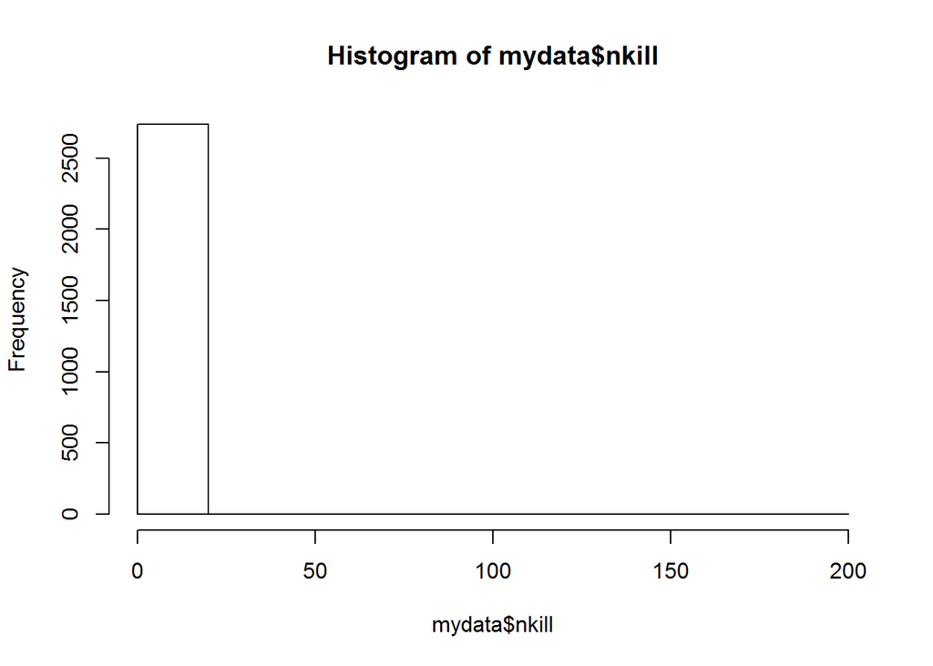

```r
hist(mydata$nkill)
```

As we can see in this histogram most of the acts of terrorism do not have fatal victims.

```r
skewness(mydata$nkill,na.rm = TRUE)
```

```
[1] 42.26456
```

This value tells us that this variable is widely asimetric, just as we have seen in the histogram

```r
kurtosis(mydata$nkill,na.rm = TRUE)
```

```
[1] 1987.84
```

This value tells us that there is an extreme peak in the distribution where most of the values are clustered. This peak is 0 as we have seen before.

#### Variable nkillus

```r
summary(mydata$nkillus)
```

```
    Min.  1st Qu.   Median     Mean  3rd Qu.     Max.
  0.0000   0.0000   0.0000   0.2341   0.0000 182.0000
```

This variable is very similar to nkill.

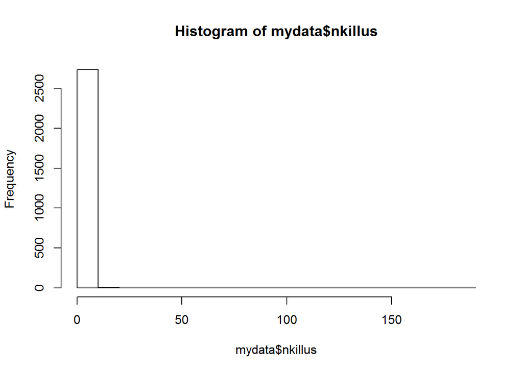

```r
hist(mydata$nkillus)
```

As we can see in this histogram most of the acts of terrorism do not have fatal victims of United States citizens.

```r
skewness(mydata$nkillus,na.rm = TRUE)
```

```
[1] 43.20675
```

This value tells us that this variable is widely asimetric, just as we have seen in the histogram.

```r
kurtosis(mydata$nperpcap,na.rm = TRUE)
```

```
[1] 10.33862
```

This value tells us that there is an extreme peak in the distribution where most of the values are clustered. This peak is 0 as we have seen before.

#### Variable nkillter

```r
summary(mydata$nkillter)
```

```
   Min. 1st Qu.  Median    Mean 3rd Qu.    Max.    NA's
  0.000   0.000   0.000   0.036   0.000   5.000     931
```

This variable is very focused on 0 considering its max value is 5.

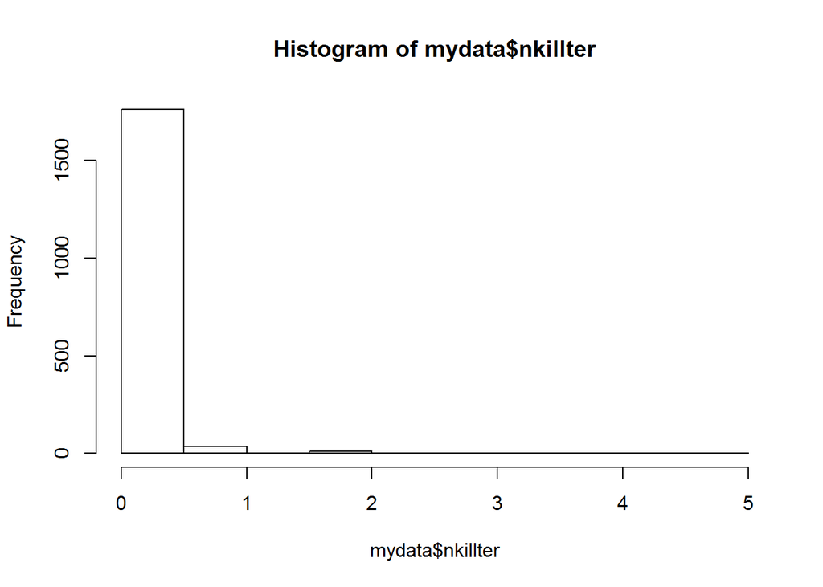

```r
hist(mydata$nkillter)
```

As we can see in this histogram most of the acts of terrorism do not have fatal victims terrorists.

```r
skewness(mydata$nkillter,na.rm = TRUE)
```

```
[1] 10.19833
```

This positive value shows us that it is an asimetric variable.

```r
kurtosis(mydata$nkillter,na.rm = TRUE)
```

```
[1] 140.5823
```

This positive value shows us that most values are clustered around a peak which is number 0 as we noticed before.

#### Variable nwound

```r
summary(mydata$nwound)
```

```
   Min. 1st Qu.  Median    Mean 3rd Qu.    Max.
  0.000   0.000   0.000   1.008   0.000 751.000
```

The maximum value of 751 is way off the mean. The 1st and 3rd quartile are 0 which tells us that most values are 0.

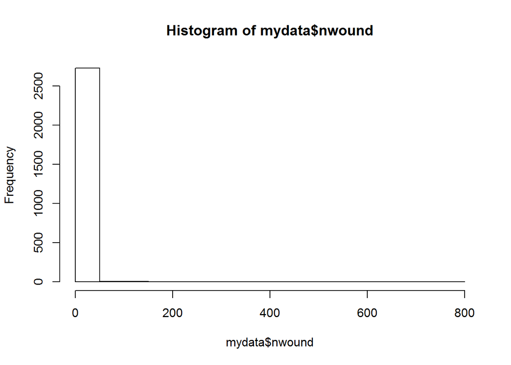

```r
hist(mydata$nwound)
```

As we can see in this histogram most of the acts of terrorism do not have wounded victims.

```r
skewness(mydata$nwound,na.rm = TRUE)
```

```
[1] 41.2821
```

This value tells us that this variable is very asimetric, just as we have seen in the histogram.

```r
kurtosis(mydata$nperpcap,na.rm = TRUE)
```

```
[1] 10.33862
```

This value tells us that there is an extreme peak in the distribution where most of the values are clustered. This peak is 0 as we have seen before.

#### Variable nwoundus

```r
summary(mydata$nwoundus)
```

```
   Min. 1st Qu.  Median    Mean 3rd Qu.    Max.    NA's
   0.00    0.00    0.00    1.07    0.00  751.00     881
```

The maximum value of 751 is way off the mean. The 1st and 3rd quartile are 0 which tells us that most values are 0.

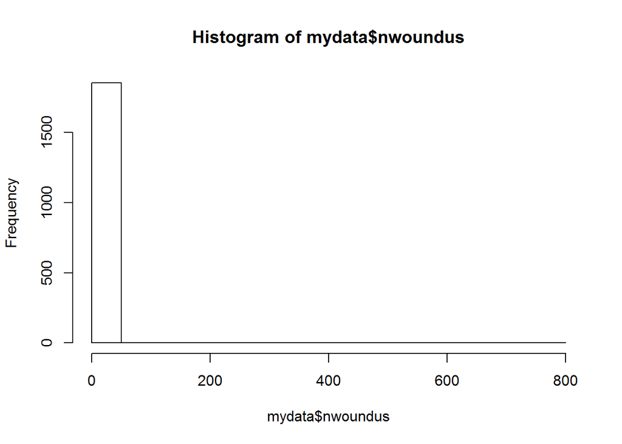

```r
hist(mydata$nwoundus)
```

As we can see in this histogram most of the acts of terrorism do not have wounded United States citizens.

```r
skewness(mydata$nwoundus,na.rm = TRUE)
```

```
[1] 38.63135
```

This positive value shows us that the variable is asimetric.

```r
kurtosis(mydata$nperpcap,na.rm = TRUE)
```

```
[1] 10.33862
```

This positive value shows us that the values are clustered around a peak which is 0 in this case.

#### Variable nwoundte

```r
summary(mydata$nwoundte)
```

```
   Min. 1st Qu.  Median    Mean 3rd Qu.    Max.    NA's
 0.0000  0.0000  0.0000  0.0465  0.0000 36.0000     932
```

This variable is very similar to nkillter. This is related to the fact that the number of perpetrators nperp is 1 most of the times.

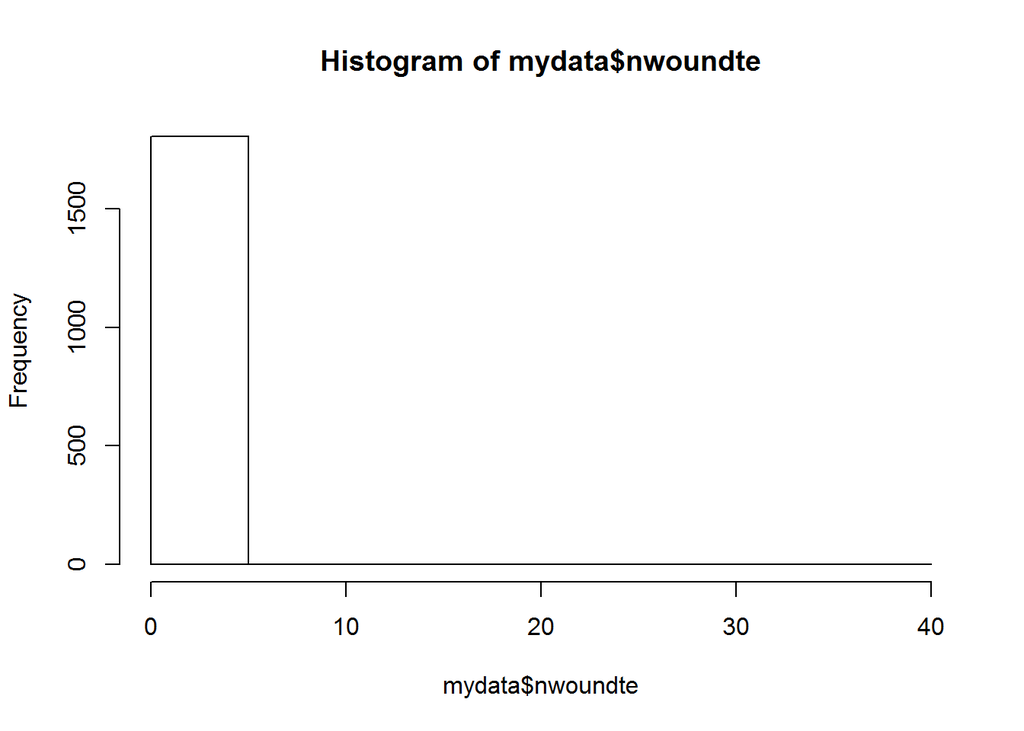

```r
hist(mydata$nwoundte)
```

As we can see in this histogram most of the acts of terrorism do not have wounded terrorists.

```r
skewness(mydata$nwoundte,na.rm = TRUE)
```

```
[1] 35.3397
```

This positive value shows us that this variable is asimetric.

```r
kurtosis(mydata$nwoundte,na.rm = TRUE)
```

```
[1] 1364.17
```

This positive value shows us that there is an extreme peak where all values are clustered around.

#### Variable propvalue

```r
summary(as.numeric(mydata$propvalue))
```

```
     Min.   1st Qu.    Median      Mean   3rd Qu.      Max.      NA's
        0      2500     20000    501607    100000 100000000      2078
```

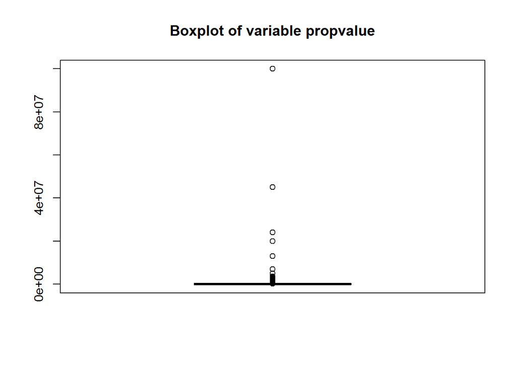

```r
mydata.propvaluelog <- sapply(as.vector(mydata$propvalue), function(x) log10(x))
boxplot(mydata$propvalue, main = "Boxplot of variable propvalue")
```

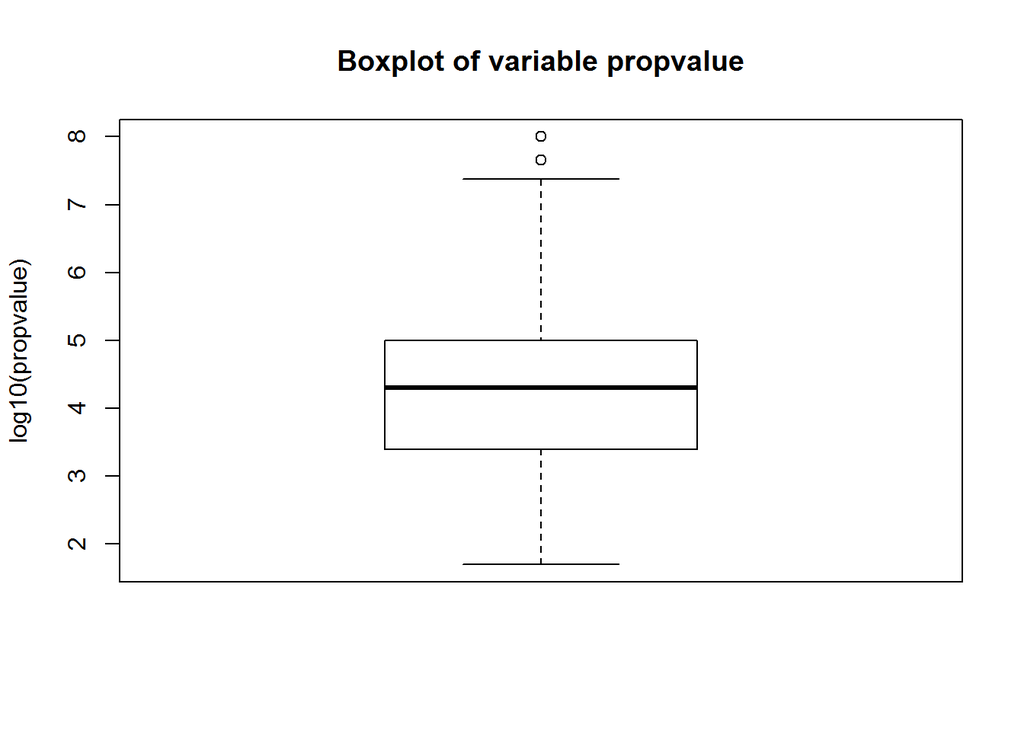

```r
boxplot(mydata.propvaluelog, main = "Boxplot of variable propvalue", ylab = "log10(propvalue)")
```

These are the boxplots for both the variable propvalue and its logarithm, because log(propvalue) is the one that appears to follow a normal distribution. We can observe that the majority of the incidents had very low valued property damage.

```r
skewness(mydata$propvalue[!is.na(mydata$propvalue)])
```

```
[1] 18.4448
```

This value tells us that this variable is very asimetric, just as we have seen before.

```r
kurtosis(mydata$propvalue[!is.na(mydata$propvalue)])
```

```
[1] 384.4994
```

This value shows us there is a big peak distribution which we know happens in the values close to 0.

#### Variable INT_IDEO

```r
summary(mydata$INT_IDEO)
```

```
   Mode   FALSE    TRUE    NA's
logical     888     434    1416
```

This pie chart indicates the proportion of ideologically international registered incidents out of the total. Only one third of them, 33%, was considered international by this criteria.

[interactive chart not shown]

#### Variable INT_MISC

```r
summary(mydata$INT_MISC)
```

```
   Mode   FALSE    TRUE    NA's
logical    2307     320     111
```

This pie chart indicates that only 12% of the registered incidents were international.

[interactive chart not shown]

#### Variable president_party

```r
summary(mydata$president_party)
```

```
Democratic Republican
       842       1896
```

This is the distribution of the number of acts of terrorism and which was the president party at the time of the incident. We can see that the majority of the incidents (69%) happened under a Republican president.

[interactive chart not shown]

#### Variable state_governor_party

```r
summary(mydata$state_governor_party)
```

```
                                  Democrat
                                      1019
                     Democrat, Independent
                                         1
                      Democrat, Republican
                                       302
                   Democratic-Farmer-Labor
                                         8
              Minnesota Independence Party
                                         3
                     New Progressive Party
                                       147
New Progressive Party of Puerto Rico (PNP)
                                         1
                  Popular Democratic Party
                                        78
                                Republican
                                       960
                                      NA's
                                       219
```

This is the distribution of the number of acts of terrorism and which was the state governor party at the time of the incident. Under the Democrat and Republican parties, the two main ones in the country, there were a similar amount of incidents (40% and 38% respectively).

[interactive chart not shown]

#### Variable date

We will not statistically analyse this variable because it makes no sense to check for any distributions or deduce conclusions with the data of the attacks since it is not a continuos variable.